# Solució de l’examen del 19 de gener de 2015 Prova A

Francesc Carmona

19/01/2015

## Problema 1

1. La condició que ha de verificar una funció paramètrica del tipus $a_1\alpha + a_2\beta + a_3\gamma$ per ser estimable és $a_1 - a_2 + a_3 = 0$
2. La funció paramètrica (i) $3\alpha -\beta -4\gamma$ és estimable. La funció paramètrica (ii) $\alpha +2\beta +2\gamma$ no és estimable.

L’estimador MQ de la funció (i) és

```r
library(MASS)
x <- c(rep(c(1,1,0),3),
       rep(c(1,2,1),3),
       rep(c(2,3,1),3),
       rep(c(0,1,1),3))
x <- matrix(x, ncol=3, byrow = T)
y <- c(-1.25,-1.28,-1.24,0.18,0.19,2.00,-1.30,-1.28,-1.31,1.12,1.13,1.11)
betas <- ginv(t(x) %*% x) %*% t(x) %*% y
t(c(3,-1,-4)) %*% betas
```

```
##           [,1]
## [1,] -9.388889
```

3. L’estimació de la covariància entre els estimadors lineals òptims de $\alpha - \gamma$ i $\alpha +\beta$ és

```r
resid <- y - x %*% betas
sigma2 <- sum(resid^2) / (12 - 2)
t(c(1,0,-1)) %*% ginv(t(x) %*% x) %*% c(1,1,0) * sigma2
```

```
##            [,1]
## [1,] 0.08322988
```

i la variància de l’estimador de $\alpha + 2\beta + \gamma$ és

```r
t(c(1,2,1)) %*% ginv(t(x) %*% x) %*% c(1,2,1) * sigma2
```

```
##            [,1]
## [1,] 0.04161494
```

4. El contrast $H_0: \gamma = 2\alpha + \beta$ es pot fer ja que la funció paramètrica $2\alpha + \beta -\gamma$ és estimable.

```r
numerador <- t(c(2,1,-1)) %*% betas
denominador <- sqrt(t(c(2,1,-1)) %*% ginv(t(x) %*% x) %*% c(2,1,-1) * sigma2)
t.est <- numerador/denominador
pt(t.est, df = 12-2)*2
```

```
##              [,1]
## [1,] 0.0001301584
```

De forma que rebutgem la hipòtesi nul·la.

## Problema 2

1. En primer lloc carreguem les dades:

```r
link <- "http://archive.ics.uci.edu/ml/machine-learning-databases/breast-cancer-wisconsin/wpbc.data"
wpbc <- read.csv(link, header=FALSE, na.strings="?")
wpbc <- na.omit(wpbc)
names_wpbc <- read.table("wpbc_names.data", header=FALSE, colClasses = "character")
colnames(wpbc) <- names_wpbc[ ,1]
rownames(wpbc) <- wpbc$ID
wpbc <- wpbc[ ,-1]
```

Ara calcularem el model de regressió. Observem que entre les variables regressores no hem de considerar la variable `Outcome`.

```r
fit <- lm(Time ~ ., data=wpbc[ ,-1])
(ss <- summary(fit))
```

```
##
## Call:
## lm(formula = Time ~ ., data = wpbc[, -1])
##
## Residuals:
##     Min      1Q  Median      3Q     Max
## -66.230 -21.285  -2.291  20.558  73.303
##
## Coefficients:
##                           Estimate Std. Error t value Pr(>|t|)
## (Intercept)             -3.504e+01  1.207e+02  -0.290  0.77198
## radius_mean              2.987e+01  2.575e+01   1.160  0.24779
## texture_mean            -1.901e+00  1.665e+00  -1.142  0.25509
## perimeter_mean          -3.965e+00  4.080e+00  -0.972  0.33260
## area_mean               -5.584e-02  1.097e-01  -0.509  0.61151
## smoothness_mean          5.831e+02  6.028e+02   0.967  0.33489
## compactness_mean        -1.388e+01  2.736e+02  -0.051  0.95960
## concavity_mean          -7.890e+01  1.885e+02  -0.419  0.67607
## concave_points_mean      2.755e+02  4.059e+02   0.679  0.49828
## symmetry_mean            2.555e+02  1.961e+02   1.303  0.19448
## fractal_dimension_mean   2.080e+02  1.266e+03   0.164  0.86969
## radius_se               -6.657e+01  7.599e+01  -0.876  0.38235
## texture_se              -1.728e+01  1.034e+01  -1.670  0.09678 .
## perimeter_se             1.623e+01  9.978e+00   1.626  0.10586
## area_se                 -2.939e-01  3.467e-01  -0.848  0.39794
## smoothness_se            5.591e+03  1.941e+03   2.880  0.00452 **
## compactness_se           8.715e+02  6.859e+02   1.271  0.20570
## concavity_se            -6.160e+02  5.505e+02  -1.119  0.26476
## concave_points_se       -4.811e+02  1.237e+03  -0.389  0.69780
## symmetry_se             -5.045e+02  6.162e+02  -0.819  0.41410
## fractal_dimension_se    -5.075e+03  5.141e+03  -0.987  0.32499
## radius_worst             5.461e+00  1.139e+01   0.480  0.63214
## texture_worst            9.881e-01  1.540e+00   0.642  0.52196
## perimeter_worst         -1.349e+00  1.149e+00  -1.175  0.24189
## area_worst               3.807e-02  6.022e-02   0.632  0.52817
## smoothness_worst        -6.239e+02  3.105e+02  -2.009  0.04617 *
## compactness_worst       -9.886e+01  8.406e+01  -1.176  0.24131
## concavity_worst          4.444e+01  6.325e+01   0.703  0.48336
## concave_points_worst    -6.287e+01  1.676e+02  -0.375  0.70809
## symmetry_worst           4.756e+01  1.090e+02   0.436  0.66332
## fractal_dimension_worst  1.010e+03  5.666e+02   1.783  0.07643 .
## Tumor_size              -9.242e-01  1.390e+00  -0.665  0.50710
## Lymph_node              -5.417e-01  4.961e-01  -1.092  0.27653
## ---
## Signif. codes:  0 '***' 0.001 '**' 0.01 '*' 0.05 '.' 0.1 ' ' 1
##
## Residual standard error: 30.88 on 161 degrees of freedom
## Multiple R-squared:  0.3325, Adjusted R-squared:  0.1998
## F-statistic: 2.506 on 32 and 161 DF,  p-value: 9.227e-05
```

El coeficient de correlació múltiple és equivalent a l’arrel quadrada del coeficient de determinació:

```r
sqrt(ss$r.squared)
```

```
## [1] 0.5766349
```

La variància estimada de l’error és

```r
ss$sigma^2
```

```
## [1] 953.6982
```

2. No és un model amb un bon ajust ja que $R^2=0.3325$ és baix. A més el $R^2$ ajustat encara és més baix. Malgrat això, la regressió és significativa ja que el p-valor és 9.227e-05. Això últim significa que la predicció pot ser útil ja que els coeficients de les variables no són conjuntament tots zero.
3. És evident que en la regressió anterior estem barrejant dues poblacions: els càncers recurrents i els no recurrents. Considerem ara només les observacions amb càncer recurrent.

```r
wpbcr <- wpbc[wpbc$Outcome == "R", -1]
```

Observem que eliminem de la base de dades la variable `Outcome` que ens pot fer nosa.

```r
fit2 <- lm(Time ~ ., data=wpbcr)
(ss2 <- summary(fit2))
```

```
##
## Call:
## lm(formula = Time ~ ., data = wpbcr)
##
## Residuals:
##     Min      1Q  Median      3Q     Max
## -34.231  -4.381  -0.686   4.714  19.584
##
## Coefficients:
##                           Estimate Std. Error t value Pr(>|t|)
## (Intercept)              1.727e+02  2.275e+02   0.759   0.4613
## radius_mean              5.229e+01  6.278e+01   0.833   0.4199
## texture_mean             4.121e-01  3.993e+00   0.103   0.9194
## perimeter_mean          -8.420e+00  8.844e+00  -0.952   0.3584
## area_mean                1.546e-01  2.382e-01   0.649   0.5278
## smoothness_mean          2.931e+03  1.442e+03   2.032   0.0631 .
## compactness_mean         2.595e+02  5.860e+02   0.443   0.6652
## concavity_mean           1.263e+03  6.429e+02   1.965   0.0711 .
## concave_points_mean     -2.496e+03  1.094e+03  -2.282   0.0399 *
## symmetry_mean            5.744e+02  3.839e+02   1.496   0.1585
## fractal_dimension_mean  -7.537e+03  3.627e+03  -2.078   0.0581 .
## radius_se               -3.133e+02  1.986e+02  -1.577   0.1388
## texture_se              -1.946e+01  2.611e+01  -0.746   0.4692
## perimeter_se             9.209e+01  3.342e+01   2.756   0.0164 *
## area_se                 -1.756e+00  7.729e-01  -2.271   0.0408 *
## smoothness_se           -5.785e+03  5.818e+03  -0.994   0.3382
## compactness_se          -1.086e+03  1.539e+03  -0.706   0.4929
## concavity_se            -9.263e+02  1.908e+03  -0.485   0.6355
## concave_points_se        2.306e+03  5.973e+03   0.386   0.7056
## symmetry_se              6.594e+02  1.683e+03   0.392   0.7016
## fractal_dimension_se    -3.908e+02  1.413e+04  -0.028   0.9784
## radius_worst             1.098e+01  2.962e+01   0.371   0.7169
## texture_worst            6.655e-01  3.033e+00   0.219   0.8297
## perimeter_worst         -5.159e+00  3.012e+00  -1.713   0.1105
## area_worst               1.192e-01  1.700e-01   0.701   0.4957
## smoothness_worst         7.199e+02  7.350e+02   0.979   0.3452
## compactness_worst        2.678e+01  2.007e+02   0.133   0.8959
## concavity_worst         -1.378e+02  1.888e+02  -0.730   0.4785
## concave_points_worst    -2.098e+02  4.892e+02  -0.429   0.6750
## symmetry_worst          -2.333e+02  2.751e+02  -0.848   0.4118
## fractal_dimension_worst  1.756e+03  1.946e+03   0.902   0.3833
## Tumor_size               7.677e-02  2.585e+00   0.030   0.9768
## Lymph_node               3.456e-01  7.479e-01   0.462   0.6516
## ---
## Signif. codes:  0 '***' 0.001 '**' 0.01 '*' 0.05 '.' 0.1 ' ' 1
##
## Residual standard error: 18.13 on 13 degrees of freedom
## Multiple R-squared:  0.8162, Adjusted R-squared:  0.3638
## F-statistic: 1.804 on 32 and 13 DF,  p-value: 0.1289
```

Ara l’ajust ja comença a ser bo $R^2=0.8162$, però ara la regressió no és significativa.

*4. Amb els gràfics o els estadístics adients, investigueu la diagnosi d’aquest model en el seguents punts*

*(i) Variància constant dels errors.*

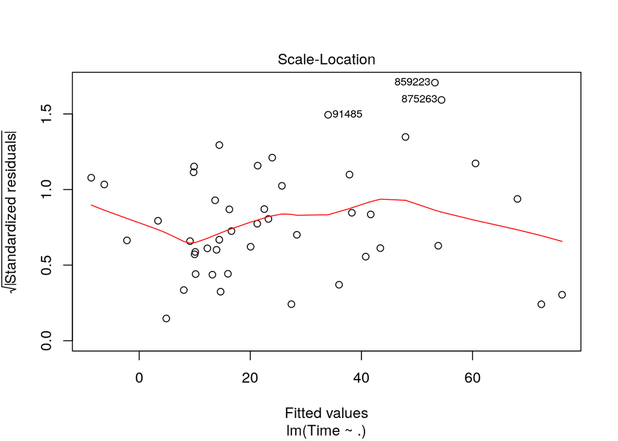

```r
plot(fit2, which=3)
```

```r
summary(lm(abs(residuals(fit2)) ~ fitted(fit2)))
```

```
##
## Call:
## lm(formula = abs(residuals(fit2)) ~ fitted(fit2))
##
## Residuals:
##     Min      1Q  Median      3Q     Max
## -10.039  -4.581  -1.671   3.173  25.068
##
## Coefficients:
##              Estimate Std. Error t value Pr(>|t|)
## (Intercept)   5.08104    1.54910   3.280  0.00203 **
## fitted(fit2)  0.07669    0.04745   1.616  0.11315
## ---
## Signif. codes:  0 '***' 0.001 '**' 0.01 '*' 0.05 '.' 0.1 ' ' 1
##
## Residual standard error: 6.535 on 44 degrees of freedom
## Multiple R-squared:  0.05605,    Adjusted R-squared:  0.0346
## F-statistic: 2.613 on 1 and 44 DF,  p-value: 0.1131
```

No sembla que hi hagi cap problema d’heterocedasticitat.

*(ii) Hipòtesi de normalitat.*

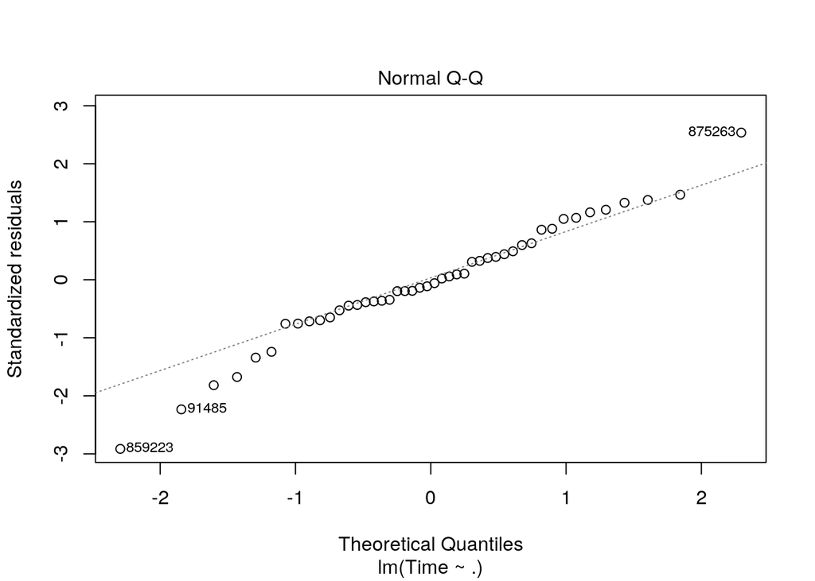

```r
plot(fit2, which=2)
```

```r
shapiro.test(residuals(fit2))
```

```
##
##  Shapiro-Wilk normality test
##
## data:  residuals(fit2)
## W = 0.9446, p-value = 0.02923
```

```r
# library(tseries)

# jarque.bera.test(residuals(fit2))
```

Segurament el problema respecte a la normalitat es degut als outliers.

```r
which(rownames(wpbcr) %in% c("875263","859223"))
```

```
## [1] 12 22
```

```r
shapiro.test(residuals(fit2)[-c(12,22)])
```

```
##
##  Shapiro-Wilk normality test
##
## data:  residuals(fit2)[-c(12, 22)]
## W = 0.9798, p-value = 0.6247
```

*(iii) Punts amb infuència potencial (leverage).*

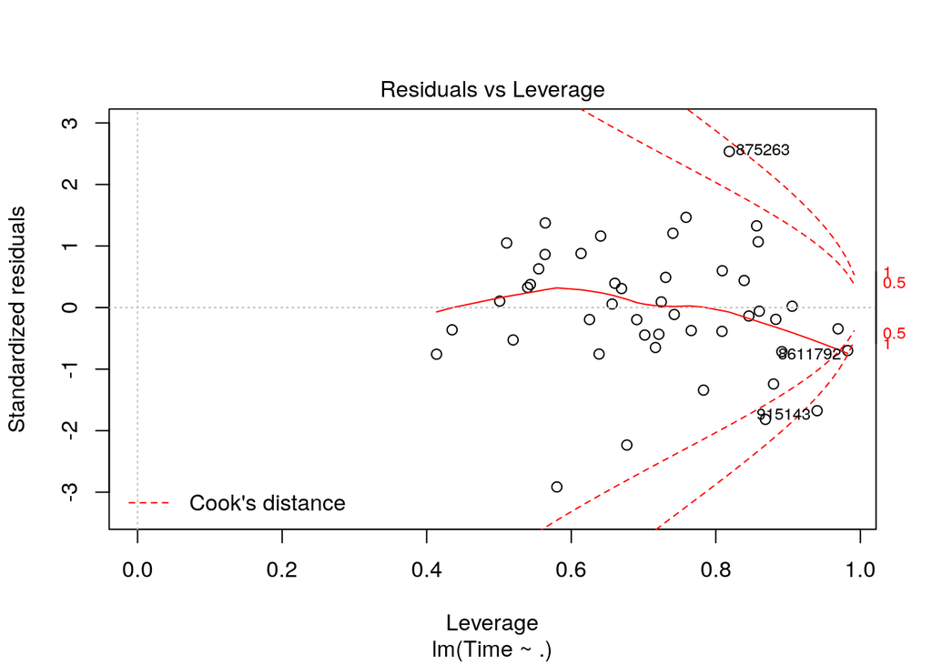

```r
plot(fit2, which=5)
```

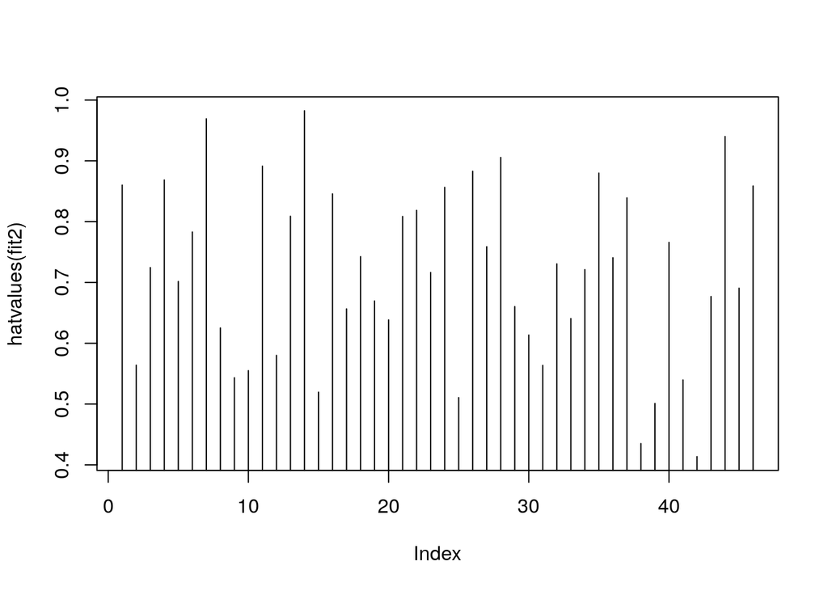

```r
plot(hatvalues(fit2),type="h")
```

```r
# sum(hatvalues(fit2))
cutoff <- 2*33/46  # =2*paràmetros/n
# abline(h=cutoff, col="red")
# which(hatvalues(fit2)>cutoff)
```

Aquí, el cutoff habitual no serveix ja que és $> 1$. No hi ha punts amb un leverage alt.

*(iv) Outliers.*

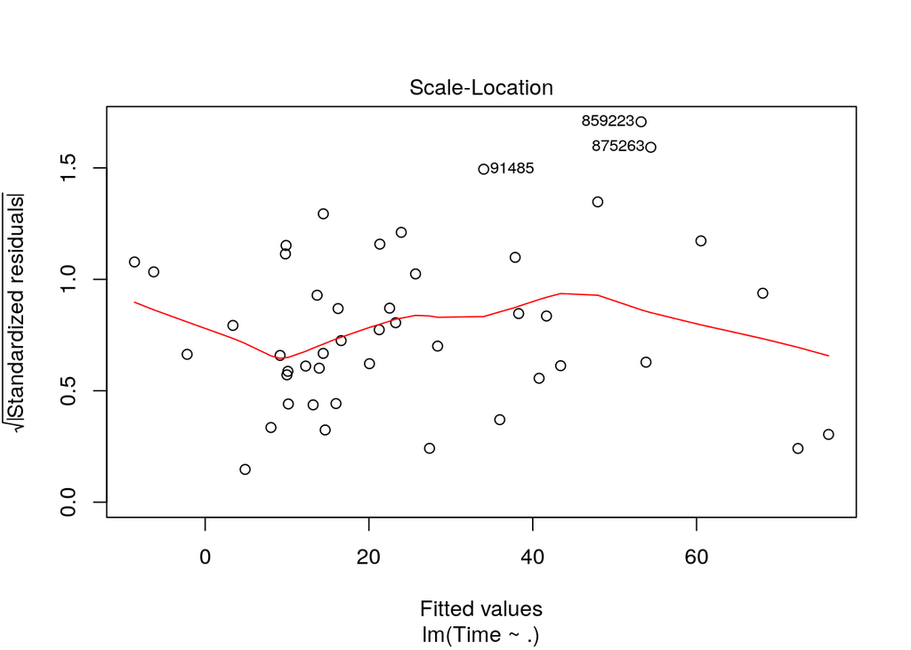

```r
plot(fit2, which=3)
```

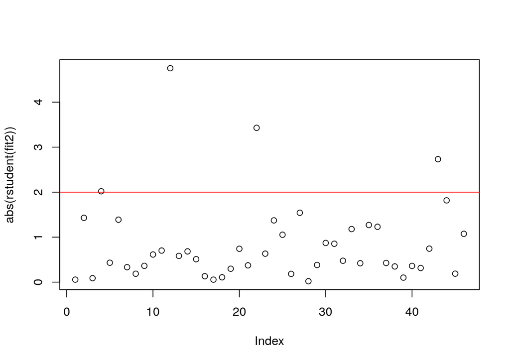

```r
plot(abs(rstudent(fit2)))
abline(h=2, col="red")
```

```r
which(abs(rstudent(fit2))>2)
```

```
## 847990 859223 875263  91485
##      4     12     22     43
```

```r
# library(car)

# outlierTest(gh)
```

Els punts 847990, 859223, 875263 i 91485 són atipics.

*(v) Punts influents.*

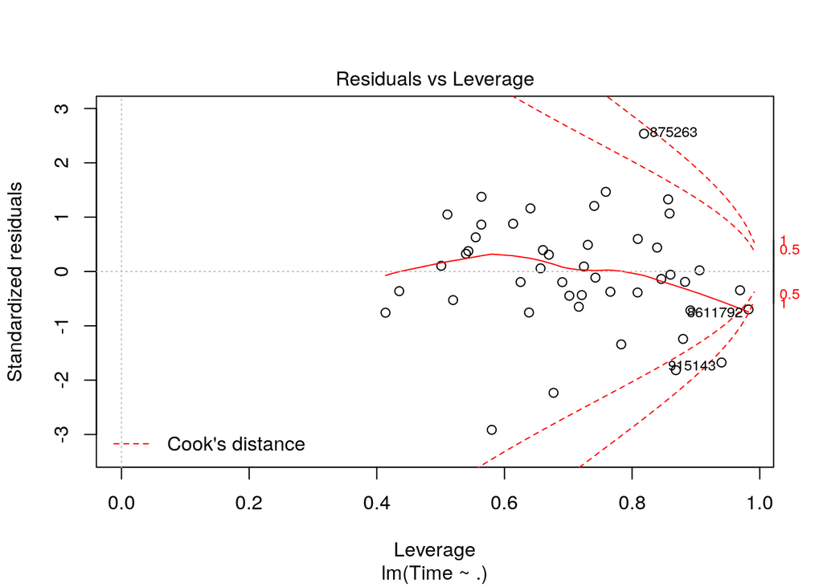

```r
plot(fit2, which=5)
```

```r
# infIndexPlot(fit2, id.n=10)
cooks.distance(fit2)
```

```
##       843584       843786       844582       847990       848620
## 0.0006361892 0.0741639426 0.0006816994 0.6608041140 0.0141723919
##       851509       855625       857010       857438       857637
## 0.1966670043 0.1131932562 0.0019091306 0.0050728226 0.0149659530
##       858986       859223       859983      8611792        86208
## 0.1276431876 0.3555124442 0.0460329221 0.8256720905 0.0090556353
##       865128       866203       867739        87112       871201
## 0.0031222287 0.0001956487 0.0011020474 0.0058732978 0.0305192615
##       873592       875263       879523       886490       887549
## 0.0190986338 0.8802349866 0.0322273968 0.3188701168 0.0348353513
##       888570       889719      8910988       892438        89539
## 0.0083213193 0.2050441874 0.0001361276 0.0091835069 0.0372141103
##        89812       898431       899987      9010018      9012000
## 0.0291498829 0.0197922745 0.0730065268 0.0147521586 0.3420813168
##       906023       908194       908489      9110732      9111805
## 0.1261281665 0.0306598885 0.0030536722 0.0003358952 0.0138205281
##       913505       914062        91485       915143       929684
## 0.0037888914 0.0122857773 0.3166833909 1.3361450450 0.0025966447
##       931652
## 0.2101042341
```

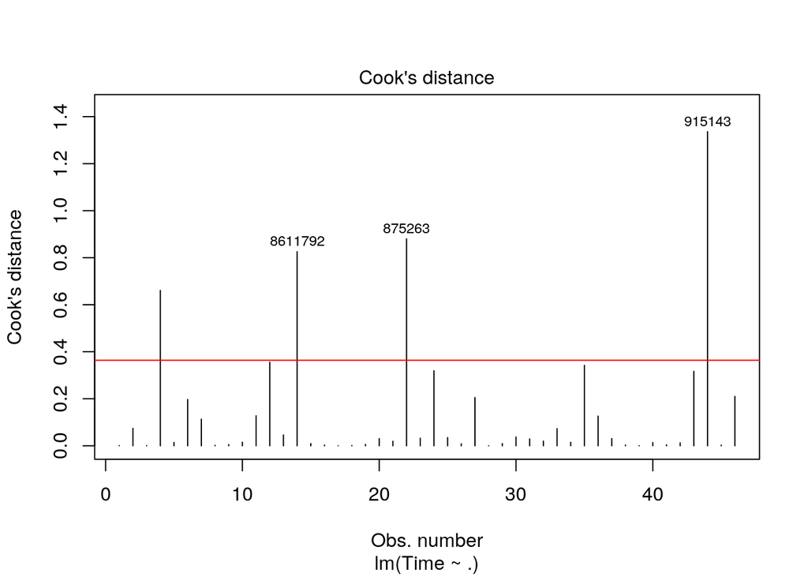

```r
# identify D values > 4/(n-k-1)
cutoff <- 4/((nrow(wpbcr)-length(fit2$coefficients)-2))
plot(fit2, which=4)
abline(h=cutoff, col="red")
```

```r
which(cooks.distance(fit2) > cutoff)
```

```
##  847990 8611792  875263  915143
##       4      14      22      44
```

```r
library(faraway)
```

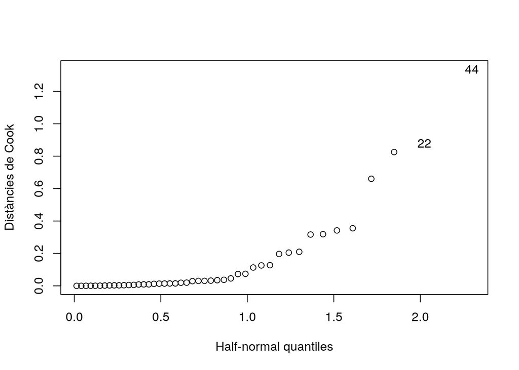

```r
halfnorm(cooks.distance(fit2), 2, ylab="Distàncies de Cook")
```

```r
#
# influence.measures(fit2)
```

*(vi) Creieu que pot haver un problema de multicolinealitat? En què us baseu?*

```r
cor(wpbcr[,-1])[1:4,1:4]
```

```
##                radius_mean texture_mean perimeter_mean   area_mean
## radius_mean     1.00000000  -0.05005084     0.99688237  0.99158951
## texture_mean   -0.05005084   1.00000000    -0.05407413 -0.07026949
## perimeter_mean  0.99688237  -0.05407413     1.00000000  0.99016752
## area_mean       0.99158951  -0.07026949     0.99016752  1.00000000
```

Les correlaciones entre les variables regressores són molt altes en alguns casos.

```r
vif(fit2)
```

```
##             radius_mean            texture_mean          perimeter_mean
##             6113.387080               29.823688             5621.764423
##               area_mean         smoothness_mean        compactness_mean
##             1226.867726               30.231721               77.862091
##          concavity_mean     concave_points_mean           symmetry_mean
##              218.572869              193.365464                8.973602
##  fractal_dimension_mean               radius_se              texture_se
##               71.463779              497.030924               16.967935
##            perimeter_se                 area_se           smoothness_se
##              749.195491              232.916024               18.452794
##          compactness_se            concavity_se       concave_points_se
##               99.297945              128.841270               76.015144
##             symmetry_se    fractal_dimension_se            radius_worst
##               32.660694               82.433559             2658.544781
##           texture_worst         perimeter_worst              area_worst
##               38.881738             1305.358226             1957.253303
##        smoothness_worst       compactness_worst         concavity_worst
##               28.437453               94.077148              106.393796
##    concave_points_worst          symmetry_worst fractal_dimension_worst
##               47.275984               39.154001              146.121682
##              Tumor_size              Lymph_node
##                3.769993                2.773489
```

Hi ha molts vif més grans que 5. Tenim un problema greu de multicolinealitat.

5. El punt 859223 és un outlier, però no un punt influent. Si l’eliminem guanyarem en l’ajust. El punt 8611792 és un punt influent. Si l’eliminem guanyariem en robustessa.
6. Veiem si els coeficients de les variables `smoothness_mean` i `concavity_mean` són iguals:

```r
fit3 <- update(fit2,.~.-smoothness_mean-concavity_mean+I(smoothness_mean+concavity_mean))
anova(fit3,fit2)
```

```
## Analysis of Variance Table
##
## Model 1: Time ~ radius_mean + texture_mean + perimeter_mean + area_mean +
##     compactness_mean + concave_points_mean + symmetry_mean +
##     fractal_dimension_mean + radius_se + texture_se + perimeter_se +
##     area_se + smoothness_se + compactness_se + concavity_se +
##     concave_points_se + symmetry_se + fractal_dimension_se +
##     radius_worst + texture_worst + perimeter_worst + area_worst +
##     smoothness_worst + compactness_worst + concavity_worst +
##     concave_points_worst + symmetry_worst + fractal_dimension_worst +
##     Tumor_size + Lymph_node + I(smoothness_mean + concavity_mean)
## Model 2: Time ~ radius_mean + texture_mean + perimeter_mean + area_mean +
##     smoothness_mean + compactness_mean + concavity_mean + concave_points_mean +
##     symmetry_mean + fractal_dimension_mean + radius_se + texture_se +
##     perimeter_se + area_se + smoothness_se + compactness_se +
##     concavity_se + concave_points_se + symmetry_se + fractal_dimension_se +
##     radius_worst + texture_worst + perimeter_worst + area_worst +
##     smoothness_worst + compactness_worst + concavity_worst +
##     concave_points_worst + symmetry_worst + fractal_dimension_worst +
##     Tumor_size + Lymph_node
##   Res.Df    RSS Df Sum of Sq      F Pr(>F)
## 1     14 4696.5
## 2     13 4271.7  1    424.82 1.2929  0.276
```

Per el p-valor calculat sembla que no hi ha prou raó per rebutjar la hipótesis de igualtat.

7. Veiem ara si les variables `Tumor_size` i `Lymph_node` són conjuntament significatives o no.

```r
fit4 <- update(fit2,.~.-Tumor_size-Lymph_node)
anova(fit4,fit2)
```

```
## Analysis of Variance Table
##
## Model 1: Time ~ radius_mean + texture_mean + perimeter_mean + area_mean +
##     smoothness_mean + compactness_mean + concavity_mean + concave_points_mean +
##     symmetry_mean + fractal_dimension_mean + radius_se + texture_se +
##     perimeter_se + area_se + smoothness_se + compactness_se +
##     concavity_se + concave_points_se + symmetry_se + fractal_dimension_se +
##     radius_worst + texture_worst + perimeter_worst + area_worst +
##     smoothness_worst + compactness_worst + concavity_worst +
##     concave_points_worst + symmetry_worst + fractal_dimension_worst
## Model 2: Time ~ radius_mean + texture_mean + perimeter_mean + area_mean +
##     smoothness_mean + compactness_mean + concavity_mean + concave_points_mean +
##     symmetry_mean + fractal_dimension_mean + radius_se + texture_se +
##     perimeter_se + area_se + smoothness_se + compactness_se +
##     concavity_se + concave_points_se + symmetry_se + fractal_dimension_se +
##     radius_worst + texture_worst + perimeter_worst + area_worst +
##     smoothness_worst + compactness_worst + concavity_worst +
##     concave_points_worst + symmetry_worst + fractal_dimension_worst +
##     Tumor_size + Lymph_node
##   Res.Df    RSS Df Sum of Sq      F Pr(>F)
## 1     15 4356.9
## 2     13 4271.7  2     85.19 0.1296 0.8795
```

No semblen significatives i escollim el model més simple.

## Problema 3

*1. Trobeu el “millor” model per dos mètodes diferents de selecció de variables com, per exemple, AIC i Cp de Mallows.*

```r
# Stepwise
sg <- step(fit2)
```

```r
summary(sg)
```

```
##
## Call:
## lm(formula = Time ~ radius_mean + perimeter_mean + smoothness_mean +
##     compactness_mean + concavity_mean + concave_points_mean +
##     symmetry_mean + fractal_dimension_mean + radius_se + texture_se +
##     perimeter_se + area_se + smoothness_se + compactness_se +
##     texture_worst + perimeter_worst + area_worst + smoothness_worst +
##     concavity_worst + symmetry_worst + fractal_dimension_worst,
##     data = wpbcr)
##
## Residuals:
##     Min      1Q  Median      3Q     Max
## -27.780  -5.553  -1.477   8.117  21.099
##
## Coefficients:
##                           Estimate Std. Error t value Pr(>|t|)
## (Intercept)              1.702e+02  1.129e+02   1.508 0.144716
## radius_mean              7.203e+01  3.566e+01   2.020 0.054684 .
## perimeter_mean          -8.344e+00  5.323e+00  -1.568 0.130087
## smoothness_mean          2.883e+03  7.926e+02   3.637 0.001311 **
## compactness_mean         3.851e+02  3.250e+02   1.185 0.247666
## concavity_mean           1.153e+03  2.798e+02   4.119 0.000390 ***
## concave_points_mean     -2.312e+03  4.570e+02  -5.058 3.59e-05 ***
## symmetry_mean            4.907e+02  2.129e+02   2.305 0.030124 *
## fractal_dimension_mean  -8.548e+03  2.265e+03  -3.773 0.000932 ***
## radius_se               -3.206e+02  7.877e+01  -4.070 0.000441 ***
## texture_se              -1.527e+01  1.415e+01  -1.079 0.291102
## perimeter_se             9.609e+01  1.684e+01   5.707 7.04e-06 ***
## area_se                 -1.723e+00  4.411e-01  -3.905 0.000669 ***
## smoothness_se           -5.761e+03  2.531e+03  -2.277 0.032020 *
## compactness_se          -1.250e+03  4.068e+02  -3.072 0.005222 **
## texture_worst            1.079e+00  8.043e-01   1.342 0.192210
## perimeter_worst         -5.742e+00  1.187e+00  -4.836 6.31e-05 ***
## area_worst               1.983e-01  4.635e-02   4.279 0.000260 ***
## smoothness_worst         7.056e+02  4.152e+02   1.699 0.102212
## concavity_worst         -1.938e+02  5.870e+01  -3.301 0.003004 **
## symmetry_worst          -1.559e+02  8.083e+01  -1.928 0.065706 .
## fractal_dimension_worst  2.169e+03  6.199e+02   3.498 0.001849 **
## ---
## Signif. codes:  0 '***' 0.001 '**' 0.01 '*' 0.05 '.' 0.1 ' ' 1
##
## Residual standard error: 14.01 on 24 degrees of freedom
## Multiple R-squared:  0.7974, Adjusted R-squared:  0.6202
## F-statistic: 4.499 on 21 and 24 DF,  p-value: 0.0002971
```

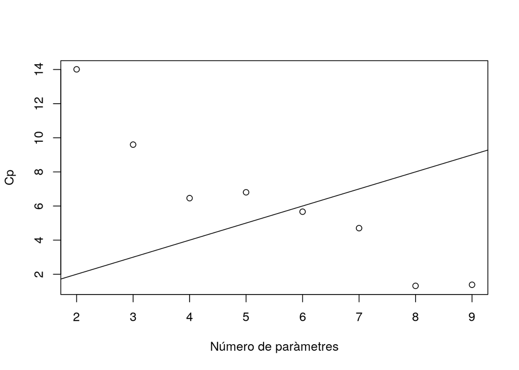

```r
# Mètode Cp de Mallows
library(leaps)
b <-regsubsets(Time ~ ., data=wpbcr)
(rs <- summary(b))
plot(2:9, rs$cp, xlab="Número de paràmetres", ylab="Cp")
abline(0,1)
```

[output not shown]

En el cas de la selecció Stepwise el model que ha quedat conté moltes variables.

En el gràfic de Cp observem que podem escollir el model de 6 paràmetres (5 variables).

*(a) Quines són les variables seleccionades?*

Amb el criteri Cp seleccionem les variables radius_mean, area_mean, smoothness_mean, concave_points_mean i smoothness_worst.

*(b) Quins són els coeficients de determinació ajustats d’aquests models? Compareu-los amb el del model complet. Llavors, què hem guanyat?*

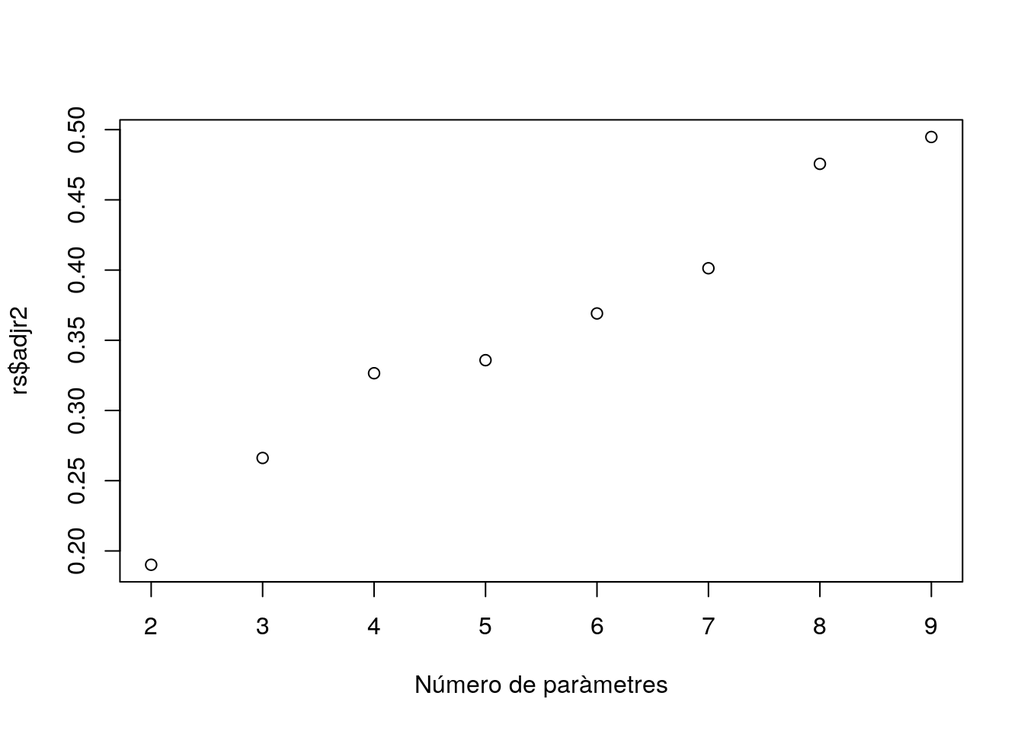

```r
plot(2:9, rs$adjr2, xlab="Número de paràmetres")
```

```r
# model complet
ss2$adj.r.squared
```

```
## [1] 0.3638347
```

```r
# model de 5 variables
rs$adjr2[5]
```

```
## [1] 0.3691248
```

```r
gs <- lm(Time ~ radius_mean + area_mean + smoothness_mean + concave_points_mean + smoothness_worst, data=wpbcr)
vif(gs)
```

```
##         radius_mean           area_mean     smoothness_mean
##           74.324694           67.480928            5.549762
## concave_points_mean    smoothness_worst
##            8.984485            3.253549
```

L’ajust del model amb 5 variables millora molt poc el coeficient de determinació ajustat i, a més, no corregeix el problema de multicolinealitat. Cal doncs reduir encara més el número de variables.

*c) Calculeu l’interval de confiança al 95% per al coeficient de regressió de la variable radius_mean en els models, el complet i els seleccionats.*

```r
confint(fit2,"radius_mean")
```

```
##                 2.5 %   97.5 %
## radius_mean -83.32968 187.9155
```

```r
confint(gs)["radius_mean", ]
```

```
##       2.5 %      97.5 %
## -28.4198853  -0.5568059
```

Hem guanyat molt en eficiència.

*2. Un altre possibilitat és fer servir la Ridge Regression. Quins són els coeficients obtinguts? Expliqueu breument les avantatges i inconvenients d’aquest mètode front a la selecció de variables.*

```r
library(MASS)
gridge <- lm.ridge(Time ~ .,data=wpbcr, lambda = seq(0,300,1))
matplot(gridge$lambda, t(gridge$coef), type="l", lty=1, xlab=expression(lambda), ylab=expression(hat(beta)))
select(gridge)
```

```
## modified HKB estimator is 0.05343388
## modified L-W estimator is 23.90176
## smallest value of GCV  at 241
```

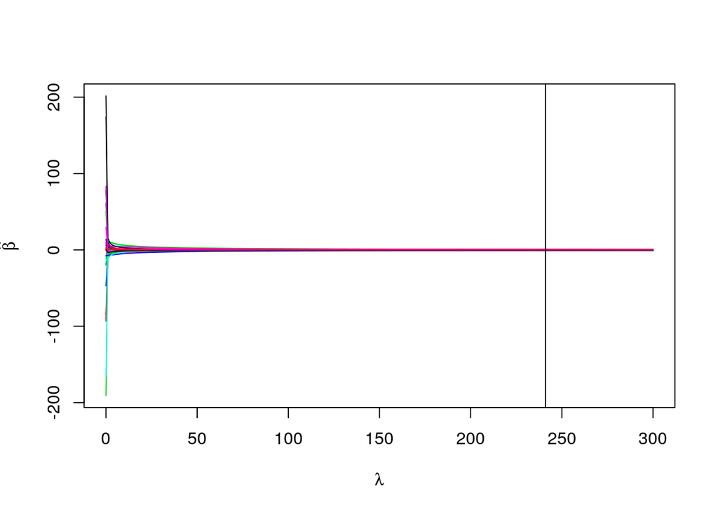

```r
abline(v=241)
```

```r
gridge <- lm.ridge(Time ~ .,data=wpbcr, lambda = 241)
coef(gridge)
```

```
##                                     radius_mean            texture_mean
##            3.055729e+01           -2.254915e-01           -1.095602e-01
##          perimeter_mean               area_mean         smoothness_mean
##           -3.288627e-02           -1.608947e-03            6.996658e+01
##        compactness_mean          concavity_mean     concave_points_mean
##           -5.539056e+00           -6.069800e+00           -1.608486e+01
##           symmetry_mean  fractal_dimension_mean               radius_se
##            3.596305e+01            1.036005e+02           -1.177038e-01
##              texture_se            perimeter_se                 area_se
##            1.266234e+00            1.046023e-02           -3.041882e-03
##           smoothness_se          compactness_se            concavity_se
##            6.839397e+01           -2.570756e+00           -1.275953e+01
##       concave_points_se             symmetry_se    fractal_dimension_se
##           -3.319630e+01           -2.752157e+01            2.792211e+02
##            radius_worst           texture_worst         perimeter_worst
##           -1.499330e-01           -2.580184e-02           -2.054250e-02
##              area_worst        smoothness_worst       compactness_worst
##           -8.062141e-04            9.925920e+00           -8.991930e-01
##         concavity_worst    concave_points_worst          symmetry_worst
##           -2.130651e+00           -2.153892e+01           -2.688251e+00
## fractal_dimension_worst              Tumor_size              Lymph_node
##            3.142075e+01           -1.179662e-01           -2.459164e-02
```

Aquest mètode permet conservar totes les variables en el model. Elimina el problema de la manca d’eficiència de les estimacions, a canvi d’un petit increment en el biaix.

En aquest problema sembla que és millor un mètode de selecció de variables.

*3. Amb el model reduït per AIC el punt 915143 és problemàtic. Ajusteu un model per un mètode robust adient per desactivar aquest problema.*

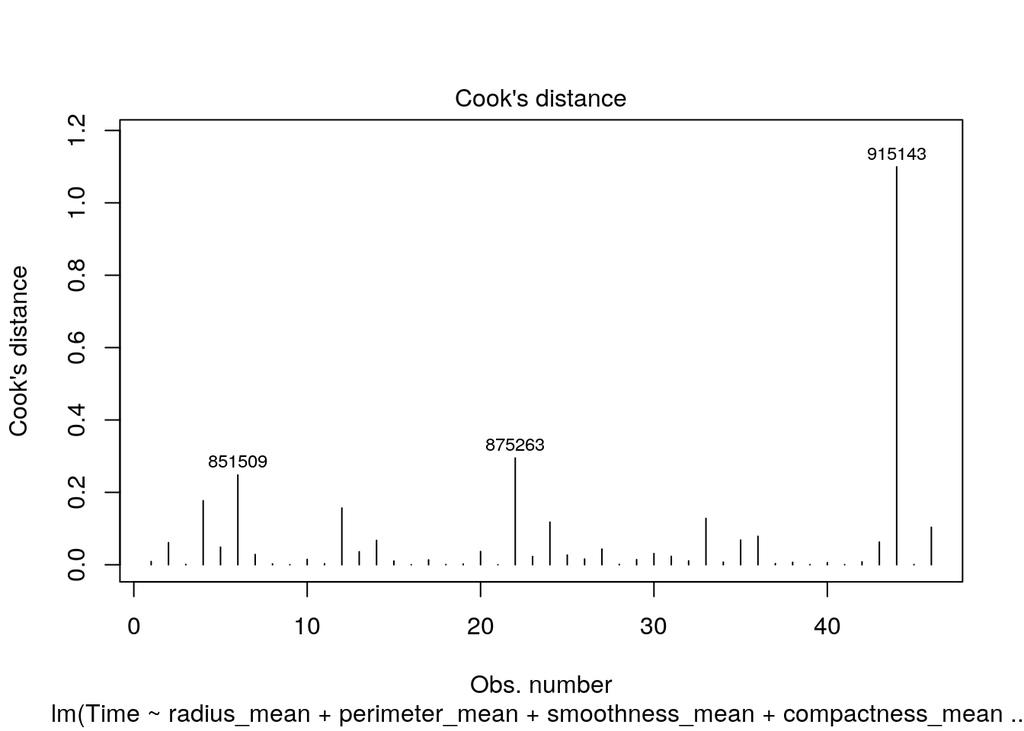

```r
gs <- step(fit2)
plot(gs, which=4)
```

```r
# Mètode least trimmed squares (LTS)
gr <- ltsreg(eval(gs$call[[2]]), data=wpbcr)
coef(gr)
```

```
##             (Intercept)             radius_mean          perimeter_mean
##            6.977335e+01            2.151971e+02           -3.067889e+01
##         smoothness_mean        compactness_mean          concavity_mean
##            4.061990e+03            6.518847e+02            1.125364e+03
##     concave_points_mean           symmetry_mean  fractal_dimension_mean
##           -1.718055e+03            3.918421e+02           -1.140315e+04
##               radius_se              texture_se            perimeter_se
##           -4.701892e+02           -5.579771e+01            1.335467e+02
##                 area_se           smoothness_se          compactness_se
##           -2.493138e+00           -3.039750e+03           -8.521617e+02
##           texture_worst         perimeter_worst              area_worst
##            1.919978e+00           -4.834957e+00            1.881916e-01
##        smoothness_worst         concavity_worst          symmetry_worst
##            4.544047e+02           -2.138413e+02           -2.115313e+02
## fractal_dimension_worst
##            3.173077e+03
```

```r
library(robustbase)
gr <- ltsReg(eval(gs$call[[2]]), data=wpbcr)
coef(gr)
```

```
##               Intercept             radius_mean          perimeter_mean
##             367.6032833             -56.6425806               9.3519146
##         smoothness_mean        compactness_mean          concavity_mean
##            4239.1942456            -542.8351463            1469.7716412
##     concave_points_mean           symmetry_mean  fractal_dimension_mean
##           -2226.6824125             278.9205121           -9511.5973598
##               radius_se              texture_se            perimeter_se
##            -300.3282456             -40.7891628             114.2180592
##                 area_se           smoothness_se          compactness_se
##              -2.7340455           -5136.9495913           -1080.3890635
##           texture_worst         perimeter_worst              area_worst
##               2.3567490              -6.5257989               0.2847166
##        smoothness_worst         concavity_worst          symmetry_worst
##             878.2038671            -242.1985232             111.1957195
## fractal_dimension_worst
##            1082.6340145
```

```r
# They strongly recommend using lmrob() instead of ltsReg
gr <- lmrob(eval(gs$call[[2]]), data=wpbcr)
coef(gr)
```

```
##             (Intercept)             radius_mean          perimeter_mean
##             234.3332362              77.4576772              -9.3812436
##         smoothness_mean        compactness_mean          concavity_mean
##            2946.1734631             460.4460638            1183.2910805
##     concave_points_mean           symmetry_mean  fractal_dimension_mean
##           -2276.6713762             494.1805284           -9863.0381648
##               radius_se              texture_se            perimeter_se
##            -346.5502796             -16.3367411             105.0830648
##                 area_se           smoothness_se          compactness_se
##              -1.9059970           -5996.8270504           -1389.6953469
##           texture_worst         perimeter_worst              area_worst
##               1.2449171              -6.1089782               0.2159274
##        smoothness_worst         concavity_worst          symmetry_worst
##             928.1312019            -207.3542702            -158.3949594
## fractal_dimension_worst
##            2283.4029627
```

## Problema 4 (Test Rainbow)

Anem a aplicar el test Rainbow a la base de dades `teengamb`.

```r
library(faraway)
data(teengamb)
g.full <- lm(gamble ~ sex + income + verbal, data=teengamb)
hh <- hatvalues(g.full)
g.central <- update(g.full, subset= hh < median(hh))
sse.full <- sum(summary(g.full)$residuals^2)
sse.central <- sum(summary(g.central)$residuals^2)
n <- dim(teengamb)[1]
m <- sum(hh < median(hh))
f.est <- ((sse.full - sse.central)/(n-m))/(sse.central/(m-4))
(p.valor <- pf(f.est, n-m, m-4, lower.tail = F))
```

```
## [1] 0.01952873
```

Segons aquest test, hem de rebutjar la hipòtesi nul·la de linealitat.

El següent test és equivalent:

```r
library(lmtest)
raintest(g.full, order.by="mahalanobis")
```

```
##
##  Rainbow test
##
## data:  g.full
## Rain = 2.5765, df1 = 24, df2 = 19, p-value = 0.01953
```